# 4_Linear_Regression

MariaGladkaya

2023-12-19

```r
knitr::opts_chunk$set(echo = TRUE)
```

## Считываем дата-сет

```r
library(readxl)
df <- read_excel("~/spbu_studies/mat_statistics/MatStat4-6/datasets/kuiper_less.xls")
View(df)
```

## Корреляционный анализ

### g. Построить график рассеяния и уравнения регрессии.

- Под глав. диагональю: графики рассеивания. Попарная зависимость
- Глав. диагон.: гистограммы. Эмпирич. аналог плотности распределения
- Над глав. диагон.: выборочные коэф-ты корреляции (критерий Пирсона) Н0: Коэф-т кор. = 0 (кор. отсутствует)

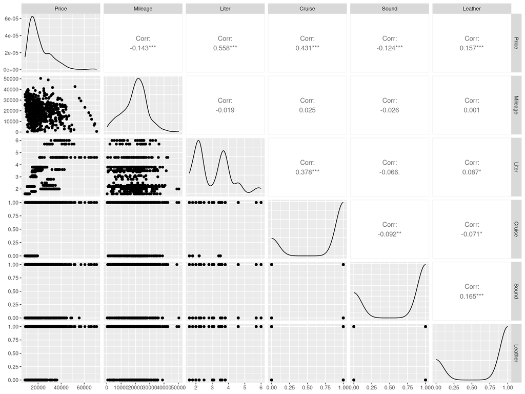

```r
library(GGally)
library(ggplot2)
ggpairs(df)
```

### a.Провести корреляционный анализ имеющихся данных.  
#### Матрица корреляции Пирсона

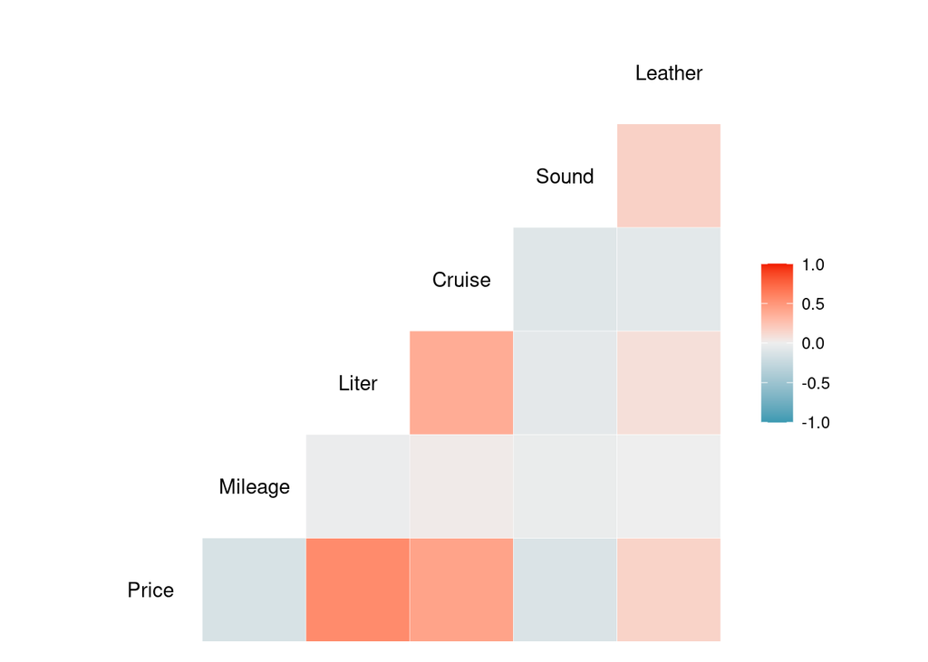

```r
ggcorr(df, method = c("everything", "pearson"))
```

#### Проверить значимость можно так же попарно

```r
cor.test(df$Price, df$Mileage)
```

```
##
##  Pearson's product-moment correlation
##
## data:  df$Price and df$Mileage
## t = -4.0932, df = 802, p-value = 4.685e-05
## alternative hypothesis: true correlation is not equal to 0
## 95 percent confidence interval:
##  -0.21011376 -0.07464739
## sample estimates:
##        cor
## -0.1430505
```

## Ур. линейной регрессии и Постороение регрессионной модели

### b. Построить базовую модель линейной регрессии.

### c. Вывести результаты анализа базовой модели.

### d. Записать уравнение линейной регрессии.

### e. Проверить значимость каждого отдельного коэффициента с помощью T-test.

### f. Проверить значимость построенного уравнения регрессии с помощью F-test.

```r
m1 <- lm(Price~Mileage+Liter+Cruise+Sound+Leather, df)
m2 <- lm(Price~Mileage+Liter+Cruise+Sound+Leather, df)
summary(m1)
```

```
##
## Call:
## lm(formula = Price ~ Mileage + Liter + Cruise + Sound + Leather,
##     data = df)
##
## Residuals:
##    Min     1Q Median     3Q    Max
## -12328  -5660  -1700   4546  38203
##
## Coefficients:
##               Estimate Std. Error t value Pr(>|t|)
## (Intercept)  7.318e+03  1.184e+03   6.182 1.01e-09 ***
## Mileage     -1.744e-01  3.265e-02  -5.342 1.20e-07 ***
## Liter        3.864e+03  2.636e+02  14.658  < 2e-16 ***
## Cruise       6.251e+03  6.741e+02   9.273  < 2e-16 ***
## Sound       -2.126e+03  5.832e+02  -3.646 0.000284 ***
## Leather      3.436e+03  6.121e+02   5.613 2.74e-08 ***
## ---
## Signif. codes:  0 '***' 0.001 '**' 0.01 '*' 0.05 '.' 0.1 ' ' 1
##
## Residual standard error: 7574 on 798 degrees of freedom
## Multiple R-squared:  0.4165, Adjusted R-squared:  0.4129
## F-statistic: 113.9 on 5 and 798 DF,  p-value: < 2.2e-16
```

#### Трактовка:

Выводится *ур. модели линейной регрессии*

*Residuals* - остатки. Разность между наблюдаемым значением и предсказанным. И для них посчитаны квантили

*Coefficients:*

- Estimate - оценки коэф-тов в ур-нии
- Std. Error, t value - стандартная ошибка и значение статистики Т
- Статистика Стьюдента Н0: коэф-т равен 0 (не значим) принимаем => не значим отвергаем => значим (р < 0.05)

*Multiple R-squared:* чем ближе к 1, тем лучше (разброс данных как можно лучше объясняется с пом. построенного ур. лин. регрессии)

**Отвергаем** Н0: ур. лин. регресси не значимо в целом (Все коэф-ты одновременно = 0) => **ур. лин. регресси значимо**

### h. Построить доверительные интервалы для коэффициентов регрессии.

```r
confint(m1)
```

```
##                     2.5 %       97.5 %
## (Intercept)  4994.5864490 9641.9468573
## Mileage        -0.2384939   -0.1103192
## Liter        3346.8251035 4381.7955991
## Cruise       4927.4989155 7573.7609344
## Sound       -3271.2466326 -981.6068347
## Leather      2234.3357222 4637.2916958
```

С вероятностью 95% значения переменных попадают в этот интервал

#### Анализ значимости регресионной модели, построенной только на одной переменной для всех переменных.

```r
anova(m1)
```

```
## Analysis of Variance Table
##
## Response: Price
##            Df     Sum Sq    Mean Sq  F value    Pr(>F)
## Mileage     1 1.6056e+09 1.6056e+09  27.9864 1.579e-07 ***
## Liter       1 2.4218e+10 2.4218e+10 422.1382 < 2.2e-16 ***
## Cruise      1 4.6132e+09 4.6132e+09  80.4112 < 2.2e-16 ***
## Sound       1 4.3503e+08 4.3503e+08   7.5828  0.006027 **
## Leather     1 1.8077e+09 1.8077e+09  31.5095 2.739e-08 ***
## Residuals 798 4.5782e+10 5.7370e+07
## ---
## Signif. codes:  0 '***' 0.001 '**' 0.01 '*' 0.05 '.' 0.1 ' ' 1
```

### j. Используя функцию Step или StepAIC, постараться улучшить модель.

Для модели смотрим по переменным, как изменится AIC при удалении(-) или прибавлении(+) той или иной переменной

```r
step(m1, direction = "both")
```

```
## Start:  AIC=14369.47
## Price ~ Mileage + Liter + Cruise + Sound + Leather
##
##           Df  Sum of Sq        RSS   AIC
## <none>                  4.5782e+10 14370
## - Sound    1 7.6266e+08 4.6544e+10 14381
## - Mileage  1 1.6371e+09 4.7419e+10 14396
## - Leather  1 1.8077e+09 4.7589e+10 14399
## - Cruise   1 4.9334e+09 5.0715e+10 14450
## - Liter    1 1.2327e+10 5.8108e+10 14559
```

```
##
## Call:
## lm(formula = Price ~ Mileage + Liter + Cruise + Sound + Leather,
##     data = df)
##
## Coefficients:
## (Intercept)      Mileage        Liter       Cruise        Sound      Leather
##   7318.2667      -0.1744    3864.3104    6250.6299   -2126.4267    3435.8137
```

В итоге выводится модель, дающая наименьший AIC

```r
library(MASS)
stepAIC(m1)
```

```
## Start:  AIC=14369.47
## Price ~ Mileage + Liter + Cruise + Sound + Leather
##
##           Df  Sum of Sq        RSS   AIC
## <none>                  4.5782e+10 14370
## - Sound    1 7.6266e+08 4.6544e+10 14381
## - Mileage  1 1.6371e+09 4.7419e+10 14396
## - Leather  1 1.8077e+09 4.7589e+10 14399
## - Cruise   1 4.9334e+09 5.0715e+10 14450
## - Liter    1 1.2327e+10 5.8108e+10 14559
```

```
##
## Call:
## lm(formula = Price ~ Mileage + Liter + Cruise + Sound + Leather,
##     data = df)
##
## Coefficients:
## (Intercept)      Mileage        Liter       Cruise        Sound      Leather
##   7318.2667      -0.1744    3864.3104    6250.6299   -2126.4267    3435.8137
```

### k. В случае получения в предыдущем пункте модели, отличной от базовой, повторить пп. c-i для новой модели.

Новая модель не была получена

## Диагностика модели линейной регрессии

### l. Построить графики: scatterplot, “Residuals vs Fitted”, “Normal Q-Q” , “Residuals vs Leverage” и дать интерпретации.

*Residuals vs Fitted* - x - оценки, полученные с пом модели лин регр

```
                    у - остатки(точки)
```

*Normal Q-Q* - анализ совместного распр. случайных величин (сопоставляются теор. и эмпир. квантили)

[output not shown]

*Residuals vs Leverage* - оценить имеются ли важные значения в выборке (которые существенно изменят модель). Они заходят за Cook’s distance

*Scale-Location* - выявить влиятельные значения

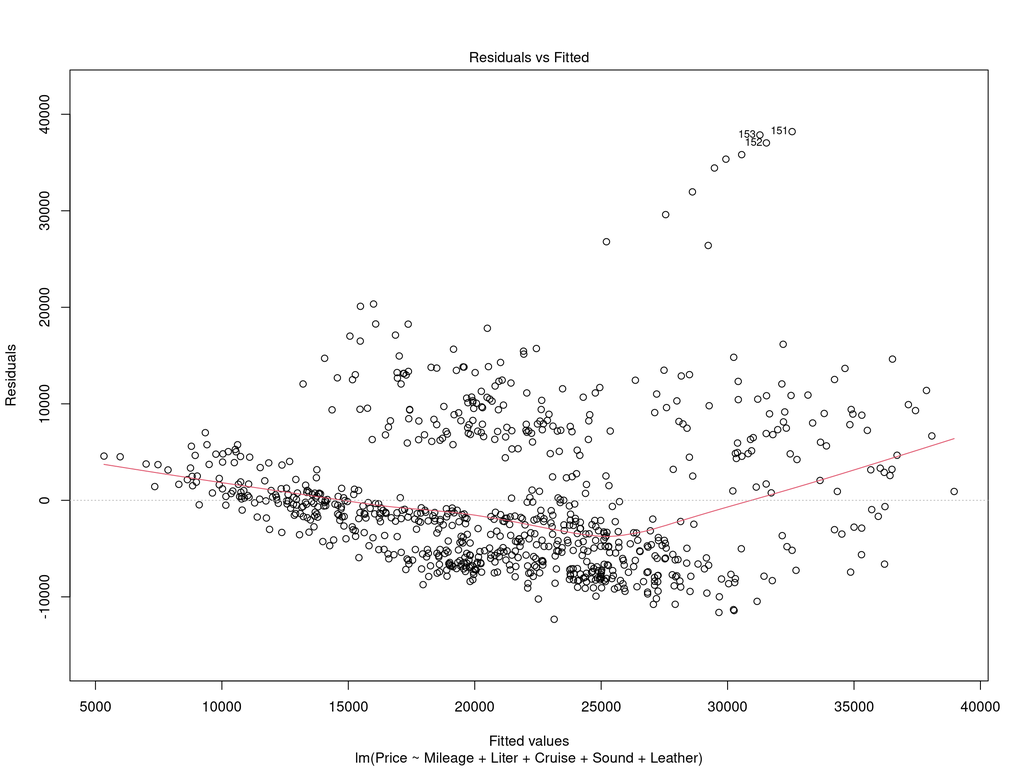

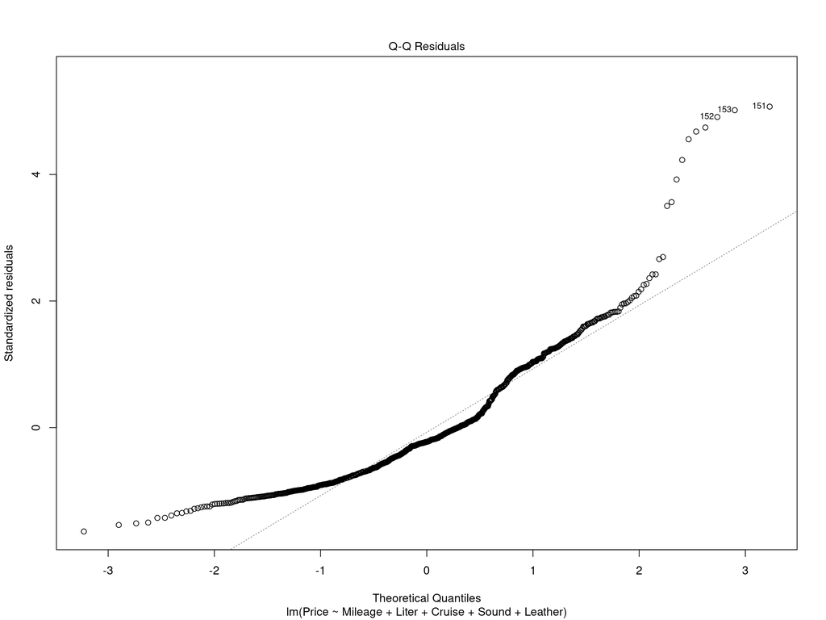

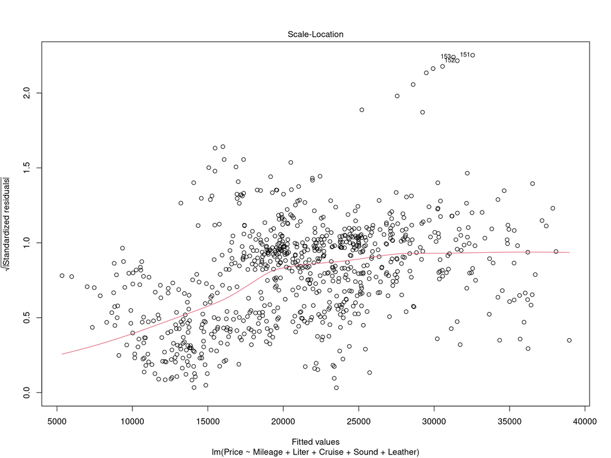

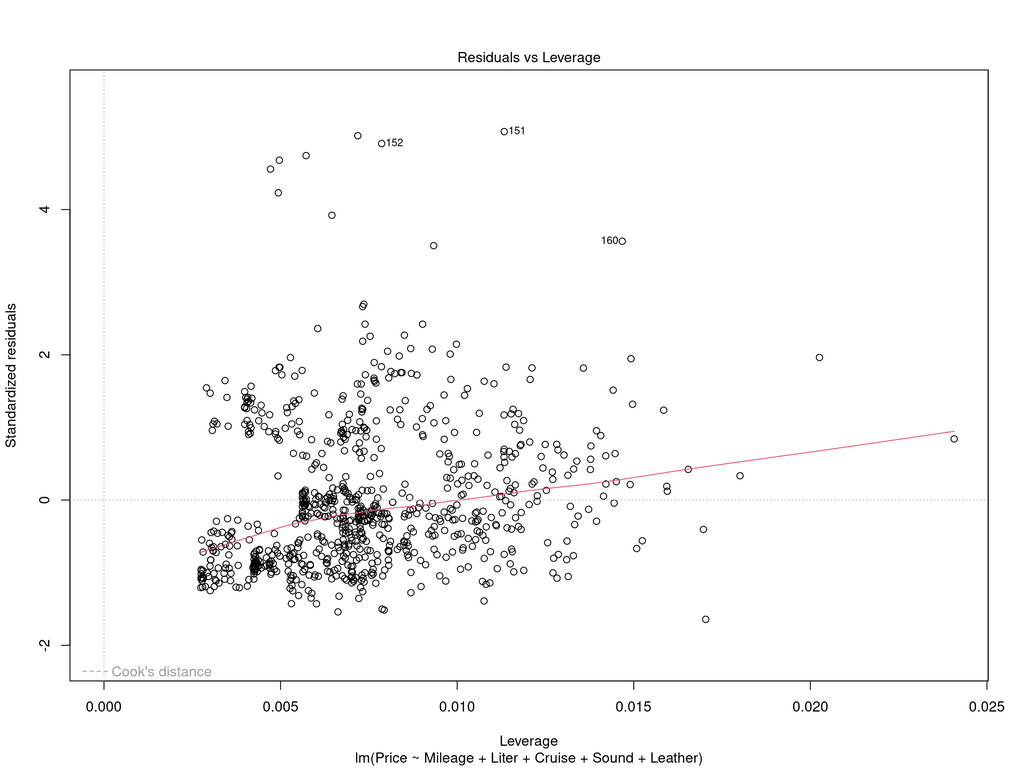

```r
plot(m2)
```

### m. Проверить модель на наличие выбросов.

```r
library(car)
outlierTest(m2, n.max=5)
```

```
##     rstudent unadjusted p-value Bonferroni p
## 151 5.153160         3.2319e-07   0.00025985
## 153 5.093800         4.3841e-07   0.00035248
## 152 4.981145         7.7535e-07   0.00062338
## 154 4.807547         1.8264e-06   0.00146850
## 155 4.741003         2.5188e-06   0.00202510
```

### n. Проверить модель на гетероскедастичность.

H0: дисперсии остатков одинаковы (гомоскедастичность) - нет проблемы H1: дисперсии остатков различны (гетероскедастичность)

```r
ncvTest(m2)
```

```
## Non-constant Variance Score Test
## Variance formula: ~ fitted.values
## Chisquare = 105.567, Df = 1, p = < 2.22e-16
```

Отвергаем Н0 => гетероскедастичность

```r
library(lmtest)
bptest(m2)
```

```
##
##  studentized Breusch-Pagan test
##
## data:  m2
## BP = 54.197, df = 5, p-value = 1.909e-10
```

### o. Проверить остатки модели на автокорреляцию.

Проверяет зависимость или независимость остатков

```r
durbinWatsonTest(m2)
```

```
##  lag Autocorrelation D-W Statistic p-value
##    1        0.847907     0.3021227       0
##  Alternative hypothesis: rho != 0
```

H0: p=0 (нет автокорреляции) р != 0 => есть автокорреляция

```r
dwtest(m2)
```

```
##
##  Durbin-Watson test
##
## data:  m2
## DW = 0.30212, p-value < 2.2e-16
## alternative hypothesis: true autocorrelation is greater than 0
```

```r
dwtest(m2, alternative = "two.sided")
```

```
##
##  Durbin-Watson test
##
## data:  m2
## DW = 0.30212, p-value < 2.2e-16
## alternative hypothesis: true autocorrelation is not 0
```

### p. Проверить остатки модели на нормальность распределения.

Везде отвергаем нормальность

```r
library(olsrr)
ols_test_normality(m2)
```

```
## -----------------------------------------------
##        Test             Statistic       pvalue
## -----------------------------------------------
## Shapiro-Wilk              0.8888         0.0000
## Kolmogorov-Smirnov        0.1238         0.0000
## Cramer-von Mises         77.7575         0.0000
## Anderson-Darling         19.5331         0.0000
## -----------------------------------------------
```

Остатки должны быть равномерно разбросаны относительно прямой у = 0

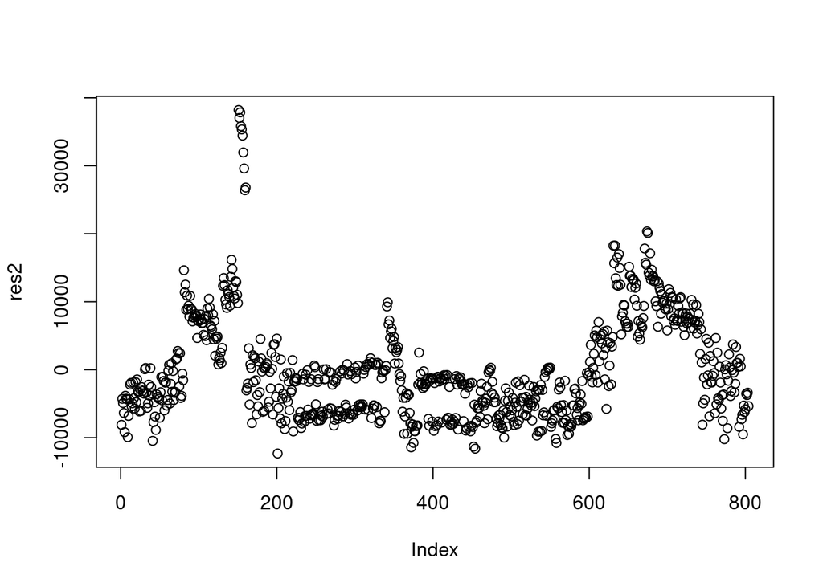

```r
library(nortest)
res2 <- residuals(m2)
plot(res2)
```

Не норм распр

```r
lillie.test(res2)
```

```
##
##  Lilliefors (Kolmogorov-Smirnov) normality test
##
## data:  res2
## D = 0.12375, p-value < 2.2e-16
```

```r
pearson.test(res2)
```

```
##
##  Pearson chi-square normality test
##
## data:  res2
## P = 268.46, p-value < 2.2e-16
```

Харке-Бера проверяет нормальность по моментам

```r
library(tseries)
jarque.bera.test(res2)
```

```
##
##  Jarque Bera Test
##
## data:  res2
## X-squared = 743.29, df = 2, p-value < 2.2e-16
```

```r
ad.test(res2)
```

```
##
##  Anderson-Darling normality test
##
## data:  res2
## A = 19.533, p-value < 2.2e-16
```

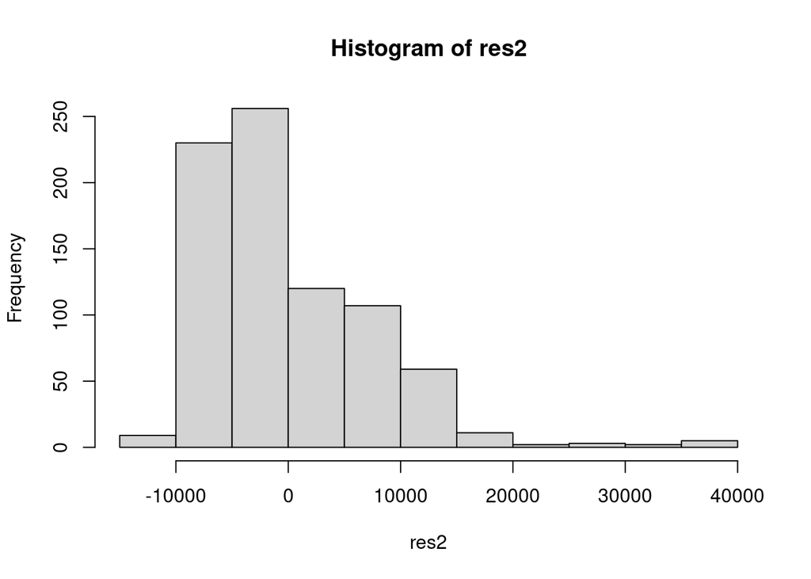

```r
hist(res2)
```

### q. Проверить модель на мультиколлинеарность данных.

Мультиколлинеарность - линейная зависимость одной независимой переменной от линейной комбинации других переменных

**Проблема мультиколлинеарности не возникает, когда все коэф-ты < 10**

```r
ols_vif_tol(m2)
```

```
##   Variables Tolerance      VIF
## 1   Mileage 0.9977109 1.002294
## 2     Liter 0.8410559 1.188982
## 3    Cruise 0.8432268 1.185921
## 4     Sound 0.9626577 1.038791
## 5   Leather 0.9529080 1.049419
```

### r. Попробовать применить трансформацию Box-Cox зависимой переменной.

Улучшение модели с пом. степенного преобразования зависимой переменной у

```r
library(MASS)
bc <- boxCox(m2)
```

[figure not shown]

вертикальные линии показывают точечные значения в которых достигается макс. знач. функции правдоподобия. + доверительный интервал

```r
which.max(bc$y)
```

```
## [1] 34
```

```r
lambda <- bc$x[which.max(bc$y)]
lambda
```

```
## [1] -0.6666667
```

Максимум функции правдоподобия (2 линия на графике)

Далее возведем зависимую переменную в эту степень

```r
z <- df$Price^lambda
df2 <- df[, -1]
df2$Price <- z
df2
```

```
## # A tibble: 804 × 6
##    Mileage Liter Cruise Sound Leather   Price
##      <dbl> <dbl>  <dbl> <dbl>   <dbl>   <dbl>
##  1    8221   3.1      1     1       1 0.00149
##  2    9135   3.1      1     1       0 0.00148
##  3   13196   3.1      1     1       0 0.00156
##  4   16342   3.1      1     0       0 0.00155
##  5   19832   3.1      1     0       1 0.00155
##  6   22236   3.1      1     1       0 0.00159
##  7   22576   3.1      1     1       0 0.00163
##  8   22964   3.1      1     1       0 0.00164
##  9   24021   3.1      1     0       1 0.00165
## 10   27325   3.1      1     1       1 0.00162
## # ℹ 794 more rows
```

```r
m3 <- lm(Price~Mileage+Liter+Cruise+Sound+Leather, df)
summary(m3)
```

```
##
## Call:
## lm(formula = Price ~ Mileage + Liter + Cruise + Sound + Leather,
##     data = df)
##
## Residuals:
##    Min     1Q Median     3Q    Max
## -12328  -5660  -1700   4546  38203
##
## Coefficients:
##               Estimate Std. Error t value Pr(>|t|)
## (Intercept)  7.318e+03  1.184e+03   6.182 1.01e-09 ***
## Mileage     -1.744e-01  3.265e-02  -5.342 1.20e-07 ***
## Liter        3.864e+03  2.636e+02  14.658  < 2e-16 ***
## Cruise       6.251e+03  6.741e+02   9.273  < 2e-16 ***
## Sound       -2.126e+03  5.832e+02  -3.646 0.000284 ***
## Leather      3.436e+03  6.121e+02   5.613 2.74e-08 ***
## ---
## Signif. codes:  0 '***' 0.001 '**' 0.01 '*' 0.05 '.' 0.1 ' ' 1
##
## Residual standard error: 7574 on 798 degrees of freedom
## Multiple R-squared:  0.4165, Adjusted R-squared:  0.4129
## F-statistic: 113.9 on 5 and 798 DF,  p-value: < 2.2e-16
```

summary для m2:

- Multiple R-squared: 0.4165, Adjusted R-squared: 0.4129
- F-statistic: 113.9 on 5 and 798 DF, p-value: < 2.2e-16

### s. В случае получения новой модели в предыдущем пункте проанализировать новую модель.

Новая модель не получена